# Risk Factor Analysis

## Outcome Variable

**Outcome Variable:** wast_rec90d

## Predictor Variables

**Intervention Variable:** impfloor

**Adjustment Set:**

- arm
- sex
- W_mage
- meducyrs
- feducyrs
- hhwealth_quart
- hfoodsec
- W_mhtcm
- W_mwtkg
- W_mbmi
- W_nrooms
- W_nchldlt5
- W_parity
- impsan
- safeh20
- delta_W_mage
- delta_meducyrs
- delta_feducyrs
- delta_hhwealth_quart
- delta_hfoodsec
- delta_W_mhtcm
- delta_W_mwtkg
- delta_W_mbmi
- delta_W_nrooms
- delta_W_nchldlt5
- delta_W_parity
- delta_impsan
- delta_safeh20

## Stratifying Variables

The analysis was stratified on these variable(s):

- agecat
- studyid
- country

## Data Summary

| agecat | studyid | country | impfloor | wast_rec90d | n_cell | n |
| --- | --- | --- | --- | --- | --- | --- |
| 0-24 months | ki0047075b-MAL-ED | BANGLADESH | 1 | 0 | 37 | 121 |
| 0-24 months | ki0047075b-MAL-ED | BANGLADESH | 1 | 1 | 73 | 121 |
| 0-24 months | ki0047075b-MAL-ED | BANGLADESH | 0 | 0 | 6 | 121 |
| 0-24 months | ki0047075b-MAL-ED | BANGLADESH | 0 | 1 | 5 | 121 |
| 0-24 months | ki0047075b-MAL-ED | BRAZIL | 1 | 0 | 6 | 24 |
| 0-24 months | ki0047075b-MAL-ED | BRAZIL | 1 | 1 | 18 | 24 |
| 0-24 months | ki0047075b-MAL-ED | BRAZIL | 0 | 0 | 0 | 24 |
| 0-24 months | ki0047075b-MAL-ED | BRAZIL | 0 | 1 | 0 | 24 |
| 0-24 months | ki0047075b-MAL-ED | INDIA | 1 | 0 | 60 | 175 |
| 0-24 months | ki0047075b-MAL-ED | INDIA | 1 | 1 | 101 | 175 |
| 0-24 months | ki0047075b-MAL-ED | INDIA | 0 | 0 | 6 | 175 |
| 0-24 months | ki0047075b-MAL-ED | INDIA | 0 | 1 | 8 | 175 |
| 0-24 months | ki0047075b-MAL-ED | NEPAL | 1 | 0 | 9 | 92 |
| 0-24 months | ki0047075b-MAL-ED | NEPAL | 1 | 1 | 34 | 92 |
| 0-24 months | ki0047075b-MAL-ED | NEPAL | 0 | 0 | 10 | 92 |
| 0-24 months | ki0047075b-MAL-ED | NEPAL | 0 | 1 | 39 | 92 |
| 0-24 months | ki0047075b-MAL-ED | PERU | 1 | 0 | 2 | 34 |
| 0-24 months | ki0047075b-MAL-ED | PERU | 1 | 1 | 5 | 34 |
| 0-24 months | ki0047075b-MAL-ED | PERU | 0 | 0 | 4 | 34 |
| 0-24 months | ki0047075b-MAL-ED | PERU | 0 | 1 | 23 | 34 |
| 0-24 months | ki0047075b-MAL-ED | SOUTH AFRICA | 1 | 0 | 13 | 80 |
| 0-24 months | ki0047075b-MAL-ED | SOUTH AFRICA | 1 | 1 | 64 | 80 |
| 0-24 months | ki0047075b-MAL-ED | SOUTH AFRICA | 0 | 0 | 0 | 80 |
| 0-24 months | ki0047075b-MAL-ED | SOUTH AFRICA | 0 | 1 | 3 | 80 |
| 0-24 months | ki0047075b-MAL-ED | TANZANIA, UNITED REPUBLIC OF | 1 | 0 | 1 | 51 |
| 0-24 months | ki0047075b-MAL-ED | TANZANIA, UNITED REPUBLIC OF | 1 | 1 | 1 | 51 |
| 0-24 months | ki0047075b-MAL-ED | TANZANIA, UNITED REPUBLIC OF | 0 | 0 | 8 | 51 |
| 0-24 months | ki0047075b-MAL-ED | TANZANIA, UNITED REPUBLIC OF | 0 | 1 | 41 | 51 |
| 0-24 months | ki1000108-CMC-V-BCS-2002 | INDIA | 1 | 0 | 78 | 223 |
| 0-24 months | ki1000108-CMC-V-BCS-2002 | INDIA | 1 | 1 | 145 | 223 |

[output cut: 162 more lines]

The following strata were considered:

- agecat: 0-24 months, studyid: ki0047075b-MAL-ED, country: BANGLADESH
- agecat: 0-24 months, studyid: ki0047075b-MAL-ED, country: BRAZIL
- agecat: 0-24 months, studyid: ki0047075b-MAL-ED, country: INDIA
- agecat: 0-24 months, studyid: ki0047075b-MAL-ED, country: NEPAL
- agecat: 0-24 months, studyid: ki0047075b-MAL-ED, country: PERU
- agecat: 0-24 months, studyid: ki0047075b-MAL-ED, country: SOUTH AFRICA
- agecat: 0-24 months, studyid: ki0047075b-MAL-ED, country: TANZANIA, UNITED REPUBLIC OF
- agecat: 0-24 months, studyid: ki1000108-CMC-V-BCS-2002, country: INDIA
- agecat: 0-24 months, studyid: ki1000108-IRC, country: INDIA
- agecat: 0-24 months, studyid: ki1017093-NIH-Birth, country: BANGLADESH
- agecat: 0-24 months, studyid: ki1017093b-PROVIDE, country: BANGLADESH
- agecat: 0-24 months, studyid: ki1017093c-NIH-Crypto, country: BANGLADESH
- agecat: 0-24 months, studyid: ki1113344-GMS-Nepal, country: NEPAL
- agecat: 0-24 months, studyid: ki1114097-CONTENT, country: PERU
- agecat: 0-24 months, studyid: kiGH5241-JiVitA-3, country: BANGLADESH
- agecat: 0-24 months, studyid: kiGH5241-JiVitA-4, country: BANGLADESH
- agecat: 0-6 months, studyid: ki0047075b-MAL-ED, country: BANGLADESH
- agecat: 0-6 months, studyid: ki0047075b-MAL-ED, country: BRAZIL
- agecat: 0-6 months, studyid: ki0047075b-MAL-ED, country: INDIA
- agecat: 0-6 months, studyid: ki0047075b-MAL-ED, country: NEPAL
- agecat: 0-6 months, studyid: ki0047075b-MAL-ED, country: PERU
- agecat: 0-6 months, studyid: ki0047075b-MAL-ED, country: SOUTH AFRICA
- agecat: 0-6 months, studyid: ki0047075b-MAL-ED, country: TANZANIA, UNITED REPUBLIC OF
- agecat: 0-6 months, studyid: ki1000108-CMC-V-BCS-2002, country: INDIA
- agecat: 0-6 months, studyid: ki1000108-IRC, country: INDIA
- agecat: 0-6 months, studyid: ki1017093-NIH-Birth, country: BANGLADESH
- agecat: 0-6 months, studyid: ki1017093b-PROVIDE, country: BANGLADESH
- agecat: 0-6 months, studyid: ki1017093c-NIH-Crypto, country: BANGLADESH
- agecat: 0-6 months, studyid: ki1113344-GMS-Nepal, country: NEPAL
- agecat: 0-6 months, studyid: ki1114097-CONTENT, country: PERU
- agecat: 0-6 months, studyid: kiGH5241-JiVitA-3, country: BANGLADESH
- agecat: 0-6 months, studyid: kiGH5241-JiVitA-4, country: BANGLADESH
- agecat: 6-24 months, studyid: ki0047075b-MAL-ED, country: BANGLADESH
- agecat: 6-24 months, studyid: ki0047075b-MAL-ED, country: BRAZIL
- agecat: 6-24 months, studyid: ki0047075b-MAL-ED, country: INDIA
- agecat: 6-24 months, studyid: ki0047075b-MAL-ED, country: NEPAL
- agecat: 6-24 months, studyid: ki0047075b-MAL-ED, country: PERU
- agecat: 6-24 months, studyid: ki0047075b-MAL-ED, country: SOUTH AFRICA
- agecat: 6-24 months, studyid: ki0047075b-MAL-ED, country: TANZANIA, UNITED REPUBLIC OF
- agecat: 6-24 months, studyid: ki1000108-CMC-V-BCS-2002, country: INDIA
- agecat: 6-24 months, studyid: ki1000108-IRC, country: INDIA
- agecat: 6-24 months, studyid: ki1017093-NIH-Birth, country: BANGLADESH
- agecat: 6-24 months, studyid: ki1017093b-PROVIDE, country: BANGLADESH
- agecat: 6-24 months, studyid: ki1017093c-NIH-Crypto, country: BANGLADESH
- agecat: 6-24 months, studyid: ki1113344-GMS-Nepal, country: NEPAL
- agecat: 6-24 months, studyid: ki1114097-CONTENT, country: PERU
- agecat: 6-24 months, studyid: kiGH5241-JiVitA-3, country: BANGLADESH
- agecat: 6-24 months, studyid: kiGH5241-JiVitA-4, country: BANGLADESH

### Dropped Strata

Some strata were dropped due to rare outcomes:

- agecat: 0-24 months, studyid: ki0047075b-MAL-ED, country: BRAZIL
- agecat: 0-24 months, studyid: ki0047075b-MAL-ED, country: PERU
- agecat: 0-24 months, studyid: ki0047075b-MAL-ED, country: SOUTH AFRICA
- agecat: 0-24 months, studyid: ki0047075b-MAL-ED, country: TANZANIA, UNITED REPUBLIC OF
- agecat: 0-24 months, studyid: ki1000108-CMC-V-BCS-2002, country: INDIA
- agecat: 0-24 months, studyid: ki1000108-IRC, country: INDIA
- agecat: 0-24 months, studyid: ki1114097-CONTENT, country: PERU
- agecat: 0-6 months, studyid: ki0047075b-MAL-ED, country: BANGLADESH
- agecat: 0-6 months, studyid: ki0047075b-MAL-ED, country: BRAZIL
- agecat: 0-6 months, studyid: ki0047075b-MAL-ED, country: INDIA
- agecat: 0-6 months, studyid: ki0047075b-MAL-ED, country: NEPAL
- agecat: 0-6 months, studyid: ki0047075b-MAL-ED, country: PERU
- agecat: 0-6 months, studyid: ki0047075b-MAL-ED, country: SOUTH AFRICA
- agecat: 0-6 months, studyid: ki0047075b-MAL-ED, country: TANZANIA, UNITED REPUBLIC OF
- agecat: 0-6 months, studyid: ki1000108-CMC-V-BCS-2002, country: INDIA
- agecat: 0-6 months, studyid: ki1000108-IRC, country: INDIA
- agecat: 0-6 months, studyid: ki1017093c-NIH-Crypto, country: BANGLADESH
- agecat: 0-6 months, studyid: ki1114097-CONTENT, country: PERU
- agecat: 6-24 months, studyid: ki0047075b-MAL-ED, country: BANGLADESH
- agecat: 6-24 months, studyid: ki0047075b-MAL-ED, country: BRAZIL
- agecat: 6-24 months, studyid: ki0047075b-MAL-ED, country: NEPAL
- agecat: 6-24 months, studyid: ki0047075b-MAL-ED, country: PERU
- agecat: 6-24 months, studyid: ki0047075b-MAL-ED, country: SOUTH AFRICA
- agecat: 6-24 months, studyid: ki0047075b-MAL-ED, country: TANZANIA, UNITED REPUBLIC OF
- agecat: 6-24 months, studyid: ki1000108-CMC-V-BCS-2002, country: INDIA
- agecat: 6-24 months, studyid: ki1000108-IRC, country: INDIA
- agecat: 6-24 months, studyid: ki1017093b-PROVIDE, country: BANGLADESH
- agecat: 6-24 months, studyid: ki1017093c-NIH-Crypto, country: BANGLADESH
- agecat: 6-24 months, studyid: ki1114097-CONTENT, country: PERU
- agecat: 6-24 months, studyid: kiGH5241-JiVitA-3, country: BANGLADESH

## Methods Detail

We’re interested in the causal parameters $E[Y_a]$ for all values of $a \in \mathcal{A}$. These parameters represent the mean outcome if, possibly contrary to fact, we intervened to set all units to have $A=a$. Under the randomization and positivity assumptions, these are identified by the statistical parameters $\psi_a=E_W[E_{Y|A,W}(Y|A=a,W)]$. In addition, we’re interested in the mean of $Y$, $E[Y]$ under no intervention (the observed mean). We will estimate these parameters by using SuperLearner to fit the relevant likelihood factors – $E_{Y|A,W}(Y|A=a,W)$ and $p(A=a|W)$, and then updating our likelihood fit using a joint TMLE.

For unadjusted analyses ($W=\{\}$), initial likelihoods were estimated using Lrnr_glm to estimate the simple $E(Y|A)$ and Lrnr_mean to estimate $p(A)$. For adjusted analyses, a small library containing Lrnr_glmnet, Lrnr_xgboost, and Lrnr_mean was used.

Having estimated these parameters, we will then use the delta method to estimate relative risks and attributable risks relative to a prespecified baseline level of $A$.

# Results Detail

## Results Plots

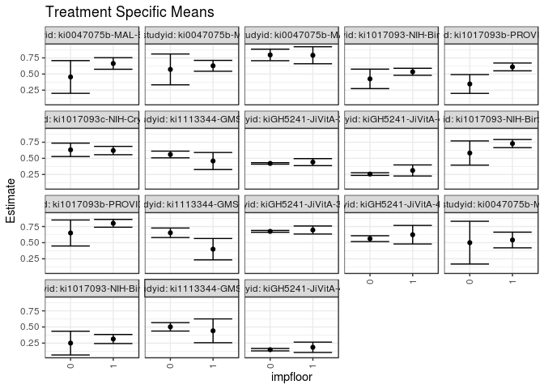

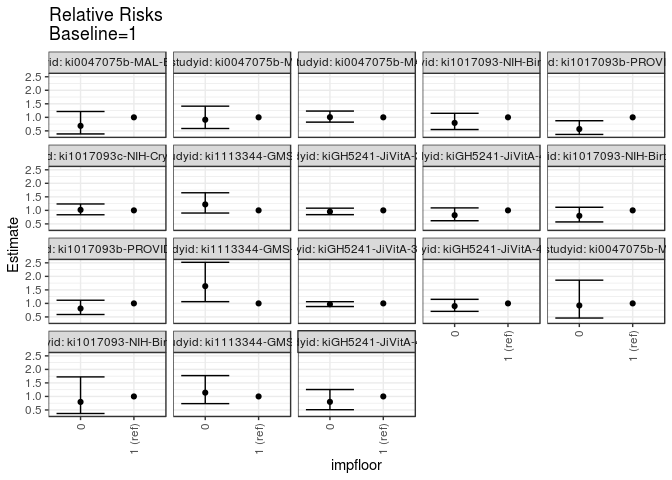

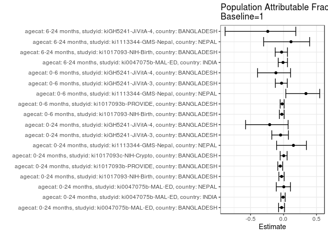

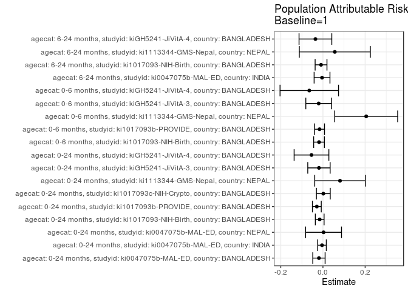

## Results Table

### Parameter: TSM

| agecat | studyid | country | intervention_level | baseline_level | estimate | ci_lower | ci_upper |
| --- | --- | --- | --- | --- | --- | --- | --- |
| 0-24 months | ki0047075b-MAL-ED | BANGLADESH | 1 | NA | 0.6636364 | 0.5737409 | 0.7535318 |
| 0-24 months | ki0047075b-MAL-ED | BANGLADESH | 0 | NA | 0.4545455 | 0.2011212 | 0.7079697 |
| 0-24 months | ki0047075b-MAL-ED | INDIA | 1 | NA | 0.6273292 | 0.5434386 | 0.7112198 |
| 0-24 months | ki0047075b-MAL-ED | INDIA | 0 | NA | 0.5714286 | 0.3326866 | 0.8101705 |
| 0-24 months | ki0047075b-MAL-ED | NEPAL | 1 | NA | 0.7906977 | 0.6589695 | 0.9224259 |
| 0-24 months | ki0047075b-MAL-ED | NEPAL | 0 | NA | 0.7959184 | 0.7066152 | 0.8852215 |
| 0-24 months | ki1017093-NIH-Birth | BANGLADESH | 1 | NA | 0.5345605 | 0.4803033 | 0.5888177 |
| 0-24 months | ki1017093-NIH-Birth | BANGLADESH | 0 | NA | 0.4248204 | 0.2741433 | 0.5754975 |
| 0-24 months | ki1017093b-PROVIDE | BANGLADESH | 1 | NA | 0.6101689 | 0.5497197 | 0.6706180 |
| 0-24 months | ki1017093b-PROVIDE | BANGLADESH | 0 | NA | 0.3459579 | 0.2002675 | 0.4916483 |
| 0-24 months | ki1017093c-NIH-Crypto | BANGLADESH | 1 | NA | 0.6208178 | 0.5563947 | 0.6852409 |
| 0-24 months | ki1017093c-NIH-Crypto | BANGLADESH | 0 | NA | 0.6322226 | 0.5284136 | 0.7360316 |
| 0-24 months | ki1113344-GMS-Nepal | NEPAL | 1 | NA | 0.4587605 | 0.3266650 | 0.5908561 |
| 0-24 months | ki1113344-GMS-Nepal | NEPAL | 0 | NA | 0.5597144 | 0.5080223 | 0.6114066 |
| 0-24 months | kiGH5241-JiVitA-3 | BANGLADESH | 1 | NA | 0.4416260 | 0.3874950 | 0.4957570 |
| 0-24 months | kiGH5241-JiVitA-3 | BANGLADESH | 0 | NA | 0.4214034 | 0.4096617 | 0.4331452 |
| 0-24 months | kiGH5241-JiVitA-4 | BANGLADESH | 1 | NA | 0.3123494 | 0.2267762 | 0.3979226 |
| 0-24 months | kiGH5241-JiVitA-4 | BANGLADESH | 0 | NA | 0.2564647 | 0.2360869 | 0.2768425 |
| 0-6 months | ki1017093-NIH-Birth | BANGLADESH | 1 | NA | 0.7289544 | 0.6660136 | 0.7918951 |
| 0-6 months | ki1017093-NIH-Birth | BANGLADESH | 0 | NA | 0.5822682 | 0.3945761 | 0.7699603 |
| 0-6 months | ki1017093b-PROVIDE | BANGLADESH | 1 | NA | 0.8000000 | 0.7395838 | 0.8604162 |
| 0-6 months | ki1017093b-PROVIDE | BANGLADESH | 0 | NA | 0.6500000 | 0.4484303 | 0.8515697 |
| 0-6 months | ki1113344-GMS-Nepal | NEPAL | 1 | NA | 0.3988554 | 0.2331775 | 0.5645332 |
| 0-6 months | ki1113344-GMS-Nepal | NEPAL | 0 | NA | 0.6530854 | 0.5791919 | 0.7269790 |
| 0-6 months | kiGH5241-JiVitA-3 | BANGLADESH | 1 | NA | 0.6959907 | 0.6337390 | 0.7582423 |
| 0-6 months | kiGH5241-JiVitA-3 | BANGLADESH | 0 | NA | 0.6748159 | 0.6608209 | 0.6888109 |
| 0-6 months | kiGH5241-JiVitA-4 | BANGLADESH | 1 | NA | 0.6232552 | 0.4797401 | 0.7667703 |
| 0-6 months | kiGH5241-JiVitA-4 | BANGLADESH | 0 | NA | 0.5618923 | 0.5166029 | 0.6071816 |
| 6-24 months | ki0047075b-MAL-ED | INDIA | 1 | NA | 0.5411765 | 0.4195451 | 0.6628078 |
| 6-24 months | ki0047075b-MAL-ED | INDIA | 0 | NA | 0.5000000 | 0.1687592 | 0.8312408 |
| 6-24 months | ki1017093-NIH-Birth | BANGLADESH | 1 | NA | 0.3136095 | 0.2434845 | 0.3837345 |
| 6-24 months | ki1017093-NIH-Birth | BANGLADESH | 0 | NA | 0.2500000 | 0.0656374 | 0.4343626 |
| 6-24 months | ki1113344-GMS-Nepal | NEPAL | 1 | NA | 0.4404574 | 0.2556623 | 0.6252526 |
| 6-24 months | ki1113344-GMS-Nepal | NEPAL | 0 | NA | 0.5021843 | 0.4368658 | 0.5675029 |
| 6-24 months | kiGH5241-JiVitA-4 | BANGLADESH | 1 | NA | 0.1849823 | 0.1050391 | 0.2649256 |
| 6-24 months | kiGH5241-JiVitA-4 | BANGLADESH | 0 | NA | 0.1480464 | 0.1294100 | 0.1666828 |

### Parameter: E(Y)

| agecat | studyid | country | intervention_level | baseline_level | estimate | ci_lower | ci_upper |
| --- | --- | --- | --- | --- | --- | --- | --- |
| 0-24 months | ki0047075b-MAL-ED | BANGLADESH | NA | NA | 0.6446281 | 0.5577732 | 0.7314830 |
| 0-24 months | ki0047075b-MAL-ED | INDIA | NA | NA | 0.6228571 | 0.5433246 | 0.7023896 |
| 0-24 months | ki0047075b-MAL-ED | NEPAL | NA | NA | 0.7934783 | 0.7160127 | 0.8709439 |
| 0-24 months | ki1017093-NIH-Birth | BANGLADESH | NA | NA | 0.5191388 | 0.4683286 | 0.5699489 |
| 0-24 months | ki1017093b-PROVIDE | BANGLADESH | NA | NA | 0.5811688 | 0.5245443 | 0.6377934 |
| 0-24 months | ki1017093c-NIH-Crypto | BANGLADESH | NA | NA | 0.6225806 | 0.5684562 | 0.6767051 |
| 0-24 months | ki1113344-GMS-Nepal | NEPAL | NA | NA | 0.5396825 | 0.4917879 | 0.5875772 |
| 0-24 months | kiGH5241-JiVitA-3 | BANGLADESH | NA | NA | 0.4226640 | 0.4115226 | 0.4338055 |
| 0-24 months | kiGH5241-JiVitA-4 | BANGLADESH | NA | NA | 0.2580019 | 0.2386523 | 0.2773515 |
| 0-6 months | ki1017093-NIH-Birth | BANGLADESH | NA | NA | 0.7104072 | 0.6505603 | 0.7702542 |
| 0-6 months | ki1017093b-PROVIDE | BANGLADESH | NA | NA | 0.7837838 | 0.7252863 | 0.8422812 |
| 0-6 months | ki1113344-GMS-Nepal | NEPAL | NA | NA | 0.6039604 | 0.5356875 | 0.6722333 |
| 0-6 months | kiGH5241-JiVitA-3 | BANGLADESH | NA | NA | 0.6757788 | 0.6624235 | 0.6891341 |
| 0-6 months | kiGH5241-JiVitA-4 | BANGLADESH | NA | NA | 0.5583942 | 0.5167799 | 0.6000084 |
| 6-24 months | ki0047075b-MAL-ED | INDIA | NA | NA | 0.5368421 | 0.4223932 | 0.6512910 |
| 6-24 months | ki1017093-NIH-Birth | BANGLADESH | NA | NA | 0.3045685 | 0.2390070 | 0.3701301 |
| 6-24 months | ki1113344-GMS-Nepal | NEPAL | NA | NA | 0.4966887 | 0.4351829 | 0.5581945 |
| 6-24 months | kiGH5241-JiVitA-4 | BANGLADESH | NA | NA | 0.1492734 | 0.1316631 | 0.1668838 |

### Parameter: RR

| agecat | studyid | country | intervention_level | baseline_level | estimate | ci_lower | ci_upper |
| --- | --- | --- | --- | --- | --- | --- | --- |
| 0-24 months | ki0047075b-MAL-ED | BANGLADESH | 1 | 1 | 1.0000000 | 1.0000000 | 1.0000000 |
| 0-24 months | ki0047075b-MAL-ED | BANGLADESH | 0 | 1 | 0.6849315 | 0.3861446 | 1.2149107 |
| 0-24 months | ki0047075b-MAL-ED | INDIA | 1 | 1 | 1.0000000 | 1.0000000 | 1.0000000 |
| 0-24 months | ki0047075b-MAL-ED | INDIA | 0 | 1 | 0.9108911 | 0.5874231 | 1.4124786 |
| 0-24 months | ki0047075b-MAL-ED | NEPAL | 1 | 1 | 1.0000000 | 1.0000000 | 1.0000000 |
| 0-24 months | ki0047075b-MAL-ED | NEPAL | 0 | 1 | 1.0066026 | 0.8227214 | 1.2315819 |
| 0-24 months | ki1017093-NIH-Birth | BANGLADESH | 1 | 1 | 1.0000000 | 1.0000000 | 1.0000000 |
| 0-24 months | ki1017093-NIH-Birth | BANGLADESH | 0 | 1 | 0.7947097 | 0.5494619 | 1.1494217 |
| 0-24 months | ki1017093b-PROVIDE | BANGLADESH | 1 | 1 | 1.0000000 | 1.0000000 | 1.0000000 |
| 0-24 months | ki1017093b-PROVIDE | BANGLADESH | 0 | 1 | 0.5669872 | 0.3676667 | 0.8743638 |
| 0-24 months | ki1017093c-NIH-Crypto | BANGLADESH | 1 | 1 | 1.0000000 | 1.0000000 | 1.0000000 |
| 0-24 months | ki1017093c-NIH-Crypto | BANGLADESH | 0 | 1 | 1.0183707 | 0.8380418 | 1.2375027 |
| 0-24 months | ki1113344-GMS-Nepal | NEPAL | 1 | 1 | 1.0000000 | 1.0000000 | 1.0000000 |
| 0-24 months | ki1113344-GMS-Nepal | NEPAL | 0 | 1 | 1.2200579 | 0.9015624 | 1.6510684 |
| 0-24 months | kiGH5241-JiVitA-3 | BANGLADESH | 1 | 1 | 1.0000000 | 1.0000000 | 1.0000000 |
| 0-24 months | kiGH5241-JiVitA-3 | BANGLADESH | 0 | 1 | 0.9542089 | 0.8416688 | 1.0817969 |
| 0-24 months | kiGH5241-JiVitA-4 | BANGLADESH | 1 | 1 | 1.0000000 | 1.0000000 | 1.0000000 |
| 0-24 months | kiGH5241-JiVitA-4 | BANGLADESH | 0 | 1 | 0.8210827 | 0.6173960 | 1.0919683 |
| 0-6 months | ki1017093-NIH-Birth | BANGLADESH | 1 | 1 | 1.0000000 | 1.0000000 | 1.0000000 |
| 0-6 months | ki1017093-NIH-Birth | BANGLADESH | 0 | 1 | 0.7987718 | 0.5724226 | 1.1146248 |
| 0-6 months | ki1017093b-PROVIDE | BANGLADESH | 1 | 1 | 1.0000000 | 1.0000000 | 1.0000000 |
| 0-6 months | ki1017093b-PROVIDE | BANGLADESH | 0 | 1 | 0.8125000 | 0.5904824 | 1.1179948 |
| 0-6 months | ki1113344-GMS-Nepal | NEPAL | 1 | 1 | 1.0000000 | 1.0000000 | 1.0000000 |
| 0-6 months | ki1113344-GMS-Nepal | NEPAL | 0 | 1 | 1.6373992 | 1.0640770 | 2.5196261 |
| 0-6 months | kiGH5241-JiVitA-3 | BANGLADESH | 1 | 1 | 1.0000000 | 1.0000000 | 1.0000000 |
| 0-6 months | kiGH5241-JiVitA-3 | BANGLADESH | 0 | 1 | 0.9695761 | 0.8847070 | 1.0625866 |
| 0-6 months | kiGH5241-JiVitA-4 | BANGLADESH | 1 | 1 | 1.0000000 | 1.0000000 | 1.0000000 |
| 0-6 months | kiGH5241-JiVitA-4 | BANGLADESH | 0 | 1 | 0.9015445 | 0.7062493 | 1.1508435 |
| 6-24 months | ki0047075b-MAL-ED | INDIA | 1 | 1 | 1.0000000 | 1.0000000 | 1.0000000 |
| 6-24 months | ki0047075b-MAL-ED | INDIA | 0 | 1 | 0.9239130 | 0.4590405 | 1.8595643 |
| 6-24 months | ki1017093-NIH-Birth | BANGLADESH | 1 | 1 | 1.0000000 | 1.0000000 | 1.0000000 |
| 6-24 months | ki1017093-NIH-Birth | BANGLADESH | 0 | 1 | 0.7971698 | 0.3690609 | 1.7218829 |
| 6-24 months | ki1113344-GMS-Nepal | NEPAL | 1 | 1 | 1.0000000 | 1.0000000 | 1.0000000 |
| 6-24 months | ki1113344-GMS-Nepal | NEPAL | 0 | 1 | 1.1401427 | 0.7340244 | 1.7709567 |
| 6-24 months | kiGH5241-JiVitA-4 | BANGLADESH | 1 | 1 | 1.0000000 | 1.0000000 | 1.0000000 |
| 6-24 months | kiGH5241-JiVitA-4 | BANGLADESH | 0 | 1 | 0.8003272 | 0.5101874 | 1.2554673 |

### Parameter: PAR

| agecat | studyid | country | intervention_level | baseline_level | estimate | ci_lower | ci_upper |
| --- | --- | --- | --- | --- | --- | --- | --- |
| 0-24 months | ki0047075b-MAL-ED | BANGLADESH | 1 | NA | -0.0190083 | -0.0482288 | 0.0102123 |
| 0-24 months | ki0047075b-MAL-ED | INDIA | 1 | NA | -0.0044720 | -0.0248142 | 0.0158701 |
| 0-24 months | ki0047075b-MAL-ED | NEPAL | 1 | NA | 0.0027806 | -0.0824301 | 0.0879912 |
| 0-24 months | ki1017093-NIH-Birth | BANGLADESH | 1 | NA | -0.0154218 | -0.0361917 | 0.0053482 |
| 0-24 months | ki1017093b-PROVIDE | BANGLADESH | 1 | NA | -0.0290001 | -0.0499810 | -0.0080191 |
| 0-24 months | ki1017093c-NIH-Crypto | BANGLADESH | 1 | NA | 0.0017629 | -0.0310642 | 0.0345900 |
| 0-24 months | ki1113344-GMS-Nepal | NEPAL | 1 | NA | 0.0809220 | -0.0389646 | 0.2008086 |
| 0-24 months | kiGH5241-JiVitA-3 | BANGLADESH | 1 | NA | -0.0189620 | -0.0720110 | 0.0340870 |
| 0-24 months | kiGH5241-JiVitA-4 | BANGLADESH | 1 | NA | -0.0543474 | -0.1367210 | 0.0280261 |
| 0-6 months | ki1017093-NIH-Birth | BANGLADESH | 1 | NA | -0.0185471 | -0.0440434 | 0.0069491 |
| 0-6 months | ki1017093b-PROVIDE | BANGLADESH | 1 | NA | -0.0162162 | -0.0398277 | 0.0073953 |
| 0-6 months | ki1113344-GMS-Nepal | NEPAL | 1 | NA | 0.2051050 | 0.0558737 | 0.3543364 |
| 0-6 months | kiGH5241-JiVitA-3 | BANGLADESH | 1 | NA | -0.0202119 | -0.0812225 | 0.0407987 |
| 0-6 months | kiGH5241-JiVitA-4 | BANGLADESH | 1 | NA | -0.0648610 | -0.2035369 | 0.0738148 |
| 6-24 months | ki0047075b-MAL-ED | INDIA | 1 | NA | -0.0043344 | -0.0419154 | 0.0332466 |
| 6-24 months | ki1017093-NIH-Birth | BANGLADESH | 1 | NA | -0.0090409 | -0.0370914 | 0.0190095 |
| 6-24 months | ki1113344-GMS-Nepal | NEPAL | 1 | NA | 0.0562313 | -0.1121569 | 0.2246195 |
| 6-24 months | kiGH5241-JiVitA-4 | BANGLADESH | 1 | NA | -0.0357089 | -0.1133804 | 0.0419626 |

### Parameter: PAF

| agecat | studyid | country | intervention_level | baseline_level | estimate | ci_lower | ci_upper |
| --- | --- | --- | --- | --- | --- | --- | --- |
| 0-24 months | ki0047075b-MAL-ED | BANGLADESH | 1 | NA | -0.0294872 | -0.0762681 | 0.0152603 |
| 0-24 months | ki0047075b-MAL-ED | INDIA | 1 | NA | -0.0071799 | -0.0403006 | 0.0248863 |
| 0-24 months | ki0047075b-MAL-ED | NEPAL | 1 | NA | 0.0035043 | -0.1100031 | 0.1054046 |
| 0-24 months | ki1017093-NIH-Birth | BANGLADESH | 1 | NA | -0.0297064 | -0.0707108 | 0.0097276 |
| 0-24 months | ki1017093b-PROVIDE | BANGLADESH | 1 | NA | -0.0498995 | -0.0869501 | -0.0141119 |
| 0-24 months | ki1017093c-NIH-Crypto | BANGLADESH | 1 | NA | 0.0028316 | -0.0513259 | 0.0541993 |
| 0-24 months | ki1113344-GMS-Nepal | NEPAL | 1 | NA | 0.1499437 | -0.1056193 | 0.3464335 |
| 0-24 months | kiGH5241-JiVitA-3 | BANGLADESH | 1 | NA | -0.0448630 | -0.1782390 | 0.0734149 |
| 0-24 months | kiGH5241-JiVitA-4 | BANGLADESH | 1 | NA | -0.2106474 | -0.5754380 | 0.0696764 |
| 0-6 months | ki1017093-NIH-Birth | BANGLADESH | 1 | NA | -0.0261077 | -0.0629029 | 0.0094137 |
| 0-6 months | ki1017093b-PROVIDE | BANGLADESH | 1 | NA | -0.0206897 | -0.0514932 | 0.0092115 |
| 0-6 months | ki1113344-GMS-Nepal | NEPAL | 1 | NA | 0.3396001 | 0.0342155 | 0.5484210 |
| 0-6 months | kiGH5241-JiVitA-3 | BANGLADESH | 1 | NA | -0.0299090 | -0.1242784 | 0.0565392 |
| 0-6 months | kiGH5241-JiVitA-4 | BANGLADESH | 1 | NA | -0.1161564 | -0.3948326 | 0.1068426 |
| 6-24 months | ki0047075b-MAL-ED | INDIA | 1 | NA | -0.0080738 | -0.0805275 | 0.0595215 |
| 6-24 months | ki1017093-NIH-Birth | BANGLADESH | 1 | NA | -0.0296844 | -0.1265874 | 0.0588835 |
| 6-24 months | ki1113344-GMS-Nepal | NEPAL | 1 | NA | 0.1132124 | -0.3021426 | 0.3960782 |
| 6-24 months | kiGH5241-JiVitA-4 | BANGLADESH | 1 | NA | -0.2392180 | -0.8862395 | 0.1858609 |